# Publicación de la Cuenta Satélite de Turismo de la Argentina

La Cuenta Satélite de Turismo de la Argentina (CST-A) proporciona el marco para la medición de la contribución del sector turístico a la economía

## Introducción

La Dirección Nacional de Mercados y Estadística (DNMyE) presenta la primera estimación y difusión, en el marco de las estadísticas oficiales de la Argentina, de una Cuenta Satélite de Turismo (CST-A). Es resultado de un proyecto conjunto de colaboración entre de la DNMyE-MINTURDEP y la Dirección Nacional de Cuentas Nacionales del Instituto Nacional de Estadística y Censos (DNCN-INDEC).

En una sección específica del [Sistema de Información Turística de la Argentina (SINTA)](https://www.yvera.tur.ar/estadistica/informe/info/cuenta-satelite-de-turismo) se puede acceder al informe técnico con información de los años 2004 y 2016-2019, el documento metodológico y los principales cuadros estadísticos.

Es el corolario de los años invertidos en el desarrollo del Sistema de Estadísticas de Turismo de la Argentina que consta de un conjunto de operaciones estadísticas e investigaciones, principalmente integrado por:

- La Encuesta de Turismo Internacional [(ETI)](https://www.yvera.tur.ar/estadistica/informe/info/turismo-internacional)
- La Encuesta de Viajes y Turismo de los Hogares [(EVyTH)](https://www.yvera.tur.ar/estadistica/informe/info/encuesta-de-viajes-y-turismo-de-los-hogares-evyth)
- La Encuesta de Ocupación Hotelera y parahotelera [(EOH)](https://www.yvera.tur.ar/estadistica/informe/info/encuesta-de-ocupacion-hotelera-eoh)
- La explotación de gran cantidad de registros administrativos (datos de tránsitos de migraciones internacionales, visitas a los parques nacionales, precios, peajes, etc).

El Sistema de Estadísticas de Turismo se integró a las cuentas nacionales de la Argentina elaboradas por el INDEC, que aportó las cuentas de producción para los sectores turísticos y los cuadros de oferta y utilización, con su reciente actualización al año 2018, que son la base para la estimación de la serie de la CST-A.

## ¿Qué es la CST?

El propósito de la CST-A es analizar minuciosamente todos los aspectos de la demanda de bienes y servicios asociados con la actividad de los visitantes argentinos y extranjeros que recorren nuestro país. Los principales resultados que muestra son una serie de indicadores económicos consistentes con las Cuentas Nacionales. Estos son:

- **Producto interno bruto directo turístico (PIBDT):** se trata de la producción de bienes y servicios que se genera directamente por el consumo de los visitantes, sin importar la industria que los produjo. Surge de contrastar el consumo total de los visitantes (turístico interno y receptor) con la producción del país.
- **Valor agregado bruto directo turístico (VABDT):** corresponde a la parte del valor agregado bruto generado por todas las industrias de una economía, ya sean turísticas o no, que atendieron directamente al consumo de los visitantes.
- **Valor agregado bruto de la industria del turismo (VABIT):** se refiere al Valor Agregado (es decir, la producción total excluyendo los consumos intermedios o insumos) de un conjunto de ramas de actividad que se consideran características del turismo (Gastronomía, Alojamiento, Transporte, Agencias de Viaje, Actividades de Entretenimiento, Culturales y Deportivas, entre otras).
- **Empleo de la industria del turismo:** corresponde al total de puestos de trabajo de las ramas de actividad características del turismo.

## Principales resultados de la CST-A

### Consumo Turístico Interior

El consumo turístico interior es el que realizan los visitantes para la adquisición de bienes o servicios en sus viajes más los otros consumos imputados. En la CST-A, se analizan distintos aspectos del gasto turístico, según la residencia de los visitantes:

• **Gasto Turístico Receptor:** referido a los visitantes no residentes en la Argentina.

• **Gasto Turístico Interno:** referido a visitantes residentes en la Argentina.

**Consumo Turístico Interior**

*En millones de pesos corrientes. Años 2004 y 2016-2019*

[output not shown]

**Fuente:** Ministerio de Turismo y Deportes. Instituto Nacional de Estadística y Censos

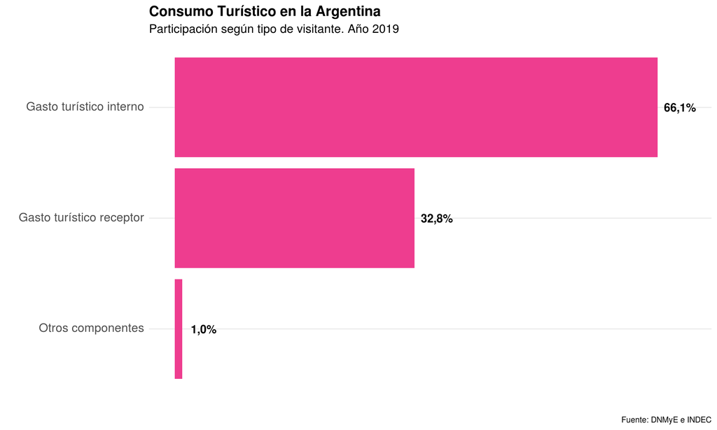

### Participación del turismo en la economía

Los indicadores que surgen de confrontar el consumo turístico con la producción de la economía (PIBdt y VABdt) permiten medir el impacto directo del turismo en la economía. En este sentido, no se tienen en cuenta otros efectos (indirectos o inducidos hacia otras ramas de la economía) asi como el gasto de capital y el consumo de gobierno relativos al turismo. Estos aspectos, asi como diferencias en la forma de medir los componentes directos, explican las discrepancias con mediciones alternativas del impacto del turismo en la economía (v.g. la medición del Consejo Mundial de Viajes y Turismo -[WTTC](https://wttc.org/Research/Economic-Impact)-)

A continuación, se presenta el PIBdt y el VABdt para los años en análisis, tanto en pesos corrientes como en porcentaje de participación sobre el PIB de la economía total.

**Producto Interno Bruto directo turístico**

*En millones de pesos corrientes y participación sobre economía total. Años 2004 y 2016-2019*

|  | 2004 | 2016 | 2017 | 2018 | 2019 |
| --- | --- | --- | --- | --- | --- |
| PIB directo turístico | 10.168 | 157.789 | 211.74 | 271.273 | 413.482 |
| PIB economía total | 485.115 | 8.228.160 | 10.660.228 | 14.744.811 | 21.802.256 |
| (%) PIBDT / PIB | 2,1 | 1,9 | 2,0 | 1,8 | 1,9 |

**Fuente:** Ministerio de Turismo y Deportes. Instituto Nacional de Estadística y Censos

El indicador PIBdt permite la comparación con otros países, en términos de la participación del turismo en la economía:

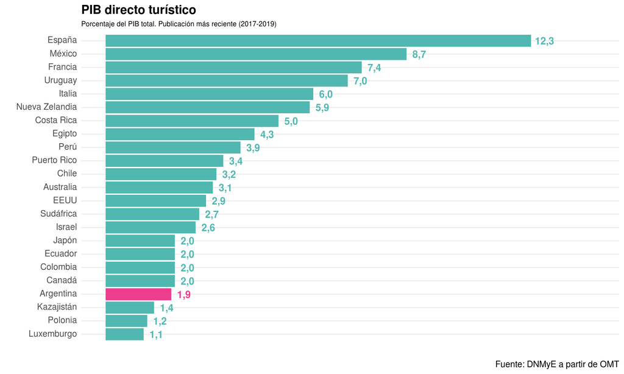

**Valor Agregado Bruto directo turístico**

*En millones de pesos corrientes y participación sobre economía total. Años 2004 y 2016-2019*

|  | 2004 | 2016 | 2017 | 2018 | 2019 |
| --- | --- | --- | --- | --- | --- |
| VAB directo turístico | 8.273 | 123.356 | 164.464 | 208.401 | 306.153 |
| VAB economía total | 412.427 | 6.947.933 | 8.993.361 | 12.478.124 | 18.340.548 |
| (%) VABDT / VAB | 2,0 | 1,8 | 1,8 | 1,7 | 1,7 |

**Fuente:** Ministerio de Turismo y Deportes. Instituto Nacional de Estadística y Censos

Asimismo, con el VABDT podemos comparar el aporte del turismo en relación con otros sectores de actividad económica del país:

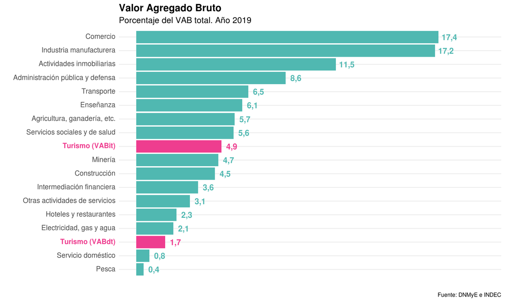

### Empleo en la industria turística

La industria turística reúne a las ramas de actividad que producen principalmente productos característicos del turismo. En base a ella se miden indicadores como el Valor agregado bruto de las industrias turísticas (VABIT) o el Empleo en las industrias turísticas.

**Puestos de trabajo en las industrias características del turismo**

*En miles y participación sobre economía total. Años 2004 y 2016-2019*

|  | 2004 | 2016 | 2017 | 2018 | 2019 |
| --- | --- | --- | --- | --- | --- |
| Empleo industrias turísticas | 931 | 1.246 | 1.274 | 1.271 | 1.260 |
| Empleo economía total | 14.911 | 20.020 | 20.345 | 20.573 | 20.855 |
| (%) Empleo IT / Empleo | 6,2 | 6,2 | 6,3 | 6,2 | 6,0 |

**Fuente:** Ministerio de Turismo y Deportes. Instituto Nacional de Estadística y Censos

En el siguiente gráfico puede observarse el aporte de las ramas características del turismo al empleo, en comparación al resto de los sectores de la economía.

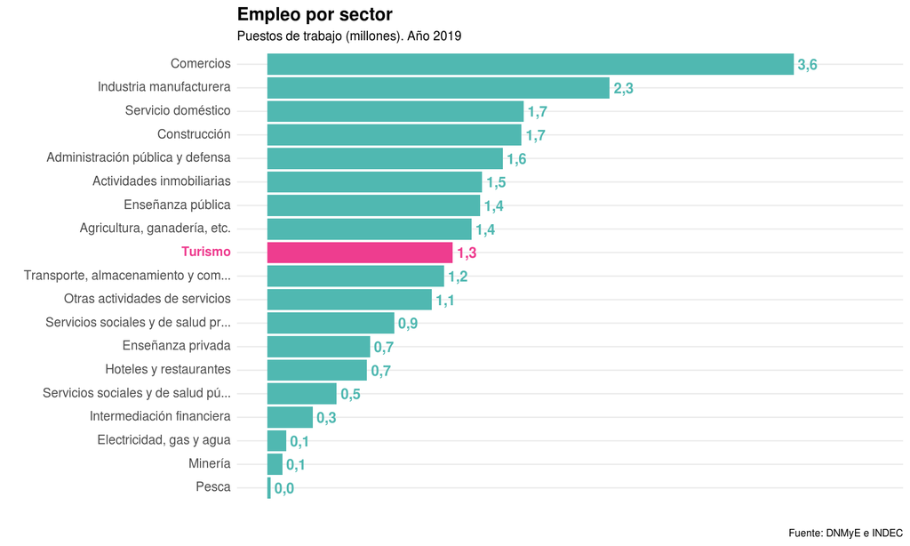

## Recursos - CST-A

[**Publicación**](https://www.yvera.tur.ar/estadistica/informe/info/cuenta-satelite-de-turismo)

[**Documento Técnico #5: Medición de la contribución económica del turismo**](https://dnme-minturdep.github.io/DT5_actividad_empleo/)

[^1]: **Fuente:** https://www.unwto.org/statistic-data-economic-contribution-of-tourism-and-beyond